# Opgavesæt 1 (PML)

2023-02-14

# Del 1: Lineære metoder til regression

Indlæs *Salgspriser.txt*. Jeg splitter datasættet i test og train med 60-40 split.

```r
library(caret)

Salgspriser <- read.delim("./Salgspriser.txt")
Salgspriser$Postnummer <- as.factor(Salgspriser$Postnummer)

# Set the seed for reproducibility
set.seed(123)

# Split the dataset into train and test sets
trainIndex <- createDataPartition(Salgspriser$Kvadratmeterpris, p = 0.6, list = FALSE)
train <- Salgspriser[trainIndex,]
test <- Salgspriser[-trainIndex,]
```

## Lineær regression (OLS)

```r
# Fit the linear regression model
lin.model <- lm(Kvadratmeterpris ~ Kvadratmeter*Postnummer + Hustype*Postnummer + AntalVarelser + Byggeaar, data = train)
koeff <- lin.model$coefficients

# Make predictions on the test set
Xmat.test <- model.matrix(Kvadratmeterpris ~ Kvadratmeter*Postnummer + Hustype*Postnummer + AntalVarelser + Byggeaar, data = test)
predictions <- Xmat.test %*% koeff

# Calculate the MSE and RMSE for the test set predictions
MSE.lin <- mean((test$Kvadratmeterpris - predictions)^2)
RMSE_OLS <- sqrt(MSE.lin)

# Print the results
cat("MSE:", MSE.lin, "\n")
```

```
## MSE: 32714675
```

```r
cat("RMSE:", RMSE_OLS, "\n")
```

```
## RMSE: 5719.674
```

## Best subset

```r
#### best subset selection


library(leaps)

fit.subset<-regsubsets(Kvadratmeterpris ~ Kvadratmeter*Postnummer + Hustype*Postnummer + AntalVarelser + Byggeaar,test,nvmax=11)
summary(fit.subset)
```

```
## Subset selection object
## Call: regsubsets.formula(Kvadratmeterpris ~ Kvadratmeter * Postnummer +
##     Hustype * Postnummer + AntalVarelser + Byggeaar, test, nvmax = 11)
## 10 Variables  (and intercept)
##                                Forced in Forced out
## Kvadratmeter                       FALSE      FALSE
## Postnummer2720                     FALSE      FALSE
## Postnummer2750                     FALSE      FALSE
## HustypeRakkehus                    FALSE      FALSE
## AntalVarelser                      FALSE      FALSE
## Byggeaar                           FALSE      FALSE
## Kvadratmeter:Postnummer2720        FALSE      FALSE
## Kvadratmeter:Postnummer2750        FALSE      FALSE
## Postnummer2720:HustypeRakkehus     FALSE      FALSE
## Postnummer2750:HustypeRakkehus     FALSE      FALSE
## 1 subsets of each size up to 10
## Selection Algorithm: exhaustive
##           Kvadratmeter Postnummer2720 Postnummer2750 HustypeRakkehus
## 1  ( 1 )  " "          "*"            " "            " "
## 2  ( 1 )  "*"          "*"            " "            " "
## 3  ( 1 )  "*"          "*"            "*"            " "
## 4  ( 1 )  "*"          "*"            "*"            " "
## 5  ( 1 )  "*"          "*"            "*"            " "
## 6  ( 1 )  "*"          "*"            "*"            " "
## 7  ( 1 )  "*"          "*"            "*"            " "
## 8  ( 1 )  "*"          "*"            "*"            "*"
## 9  ( 1 )  "*"          "*"            "*"            "*"
## 10  ( 1 ) "*"          "*"            "*"            "*"
##           AntalVarelser Byggeaar Kvadratmeter:Postnummer2720
## 1  ( 1 )  " "           " "      " "
## 2  ( 1 )  " "           " "      " "
## 3  ( 1 )  " "           " "      " "
## 4  ( 1 )  " "           " "      " "
## 5  ( 1 )  " "           "*"      " "
## 6  ( 1 )  " "           "*"      " "
## 7  ( 1 )  " "           "*"      " "
## 8  ( 1 )  " "           "*"      " "
## 9  ( 1 )  "*"           "*"      " "
## 10  ( 1 ) "*"           "*"      "*"
##           Kvadratmeter:Postnummer2750 Postnummer2720:HustypeRakkehus
## 1  ( 1 )  " "                         " "
## 2  ( 1 )  " "                         " "
## 3  ( 1 )  " "                         " "
## 4  ( 1 )  " "                         "*"
## 5  ( 1 )  " "                         "*"
## 6  ( 1 )  "*"                         "*"
## 7  ( 1 )  "*"                         "*"
## 8  ( 1 )  "*"                         "*"
## 9  ( 1 )  "*"                         "*"
## 10  ( 1 ) "*"                         "*"
##           Postnummer2750:HustypeRakkehus
## 1  ( 1 )  " "
## 2  ( 1 )  " "
## 3  ( 1 )  " "
## 4  ( 1 )  " "
## 5  ( 1 )  " "
## 6  ( 1 )  " "
## 7  ( 1 )  "*"
## 8  ( 1 )  "*"
## 9  ( 1 )  "*"
## 10  ( 1 ) "*"
```

```r
summary(fit.subset)$rss
```

```
##  [1] 8724738615 7847968342 7794938704 7749650166 7723076874 7701529564
##  [7] 7676888587 7669246153 7668319723 7667680687
```

```r
summary(fit.subset)$rsq
```

```
##  [1] 0.1710562 0.2543587 0.2593971 0.2637000 0.2662248 0.2682720 0.2706132
##  [8] 0.2713393 0.2714273 0.2714880
```

```r
summary(fit.subset)$adjr2
```

```
##  [1] 0.1678556 0.2485786 0.2507520 0.2521953 0.2518370 0.2509871 0.2504325
##  [8] 0.2482072 0.2453032 0.2423475
```

```r
summary(fit.subset)$cp
```

```
##  [1] 27.4647218  0.8781678  1.1491691  1.6725643  2.8061585  4.1036218
##  [7]  5.3002179  7.0510411  9.0208354 11.0000000
```

```r
summary(fit.subset)$bic
```

```
##  [1] -37.83531 -59.91273 -56.11780 -52.07411 -47.40609 -42.57077 -37.84266
##  [8] -32.53809 -27.00510 -21.46234
```

```r
## prædiktion
Xmat.test<-model.matrix(Kvadratmeterpris ~ Kvadratmeter*Postnummer + Hustype*Postnummer + AntalVarelser + Byggeaar,data=test)

coef_BSS<-coef(fit.subset,id=2)
predictions<-Xmat.test[,names(coef_BSS)]%*%coef_BSS
MSE_BSS <- mean((test$Kvadratmeterpris-predictions)^2)
RMSE_BSS <- sqrt(MSE_BSS)
```

## Ridge

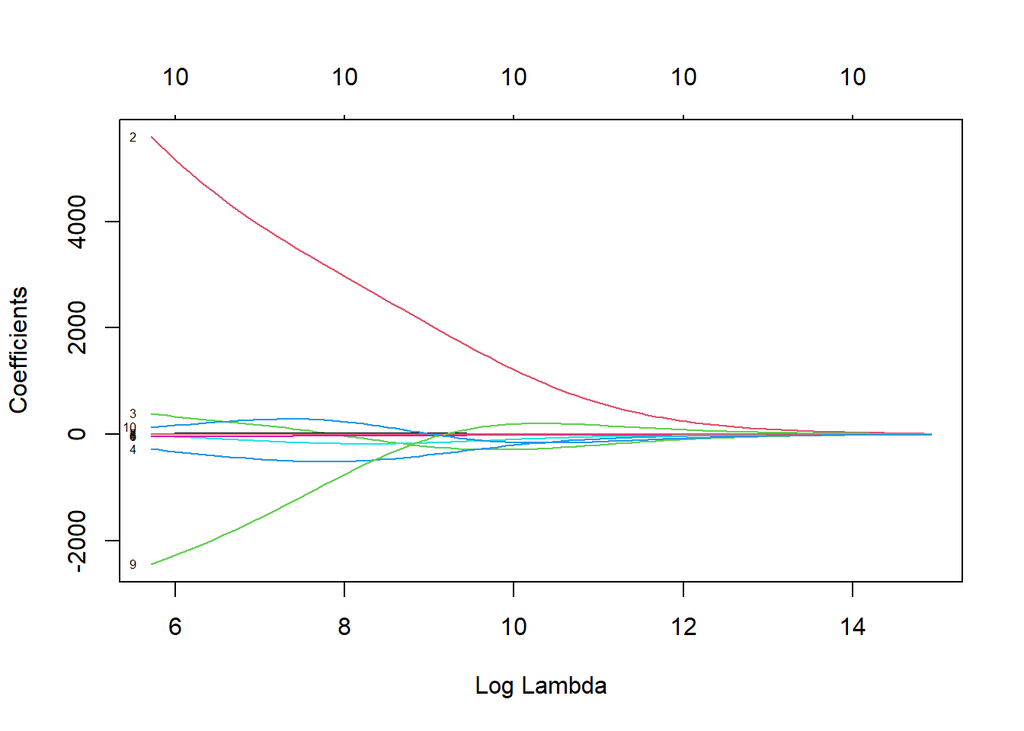

```r
library(glmnet)

x <- model.matrix(Kvadratmeterpris ~ Kvadratmeter*Postnummer + Hustype*Postnummer + AntalVarelser + Byggeaar, train)[, -1]
y <- train$Kvadratmeterpris
ridge.mod <- glmnet(x, y, alpha = 0)

plot(ridge.mod,label=TRUE,xvar='lambda')
```

```r
x_test <- model.matrix(Kvadratmeterpris ~ Kvadratmeter*Postnummer + Hustype*Postnummer + AntalVarelser + Byggeaar, test)[, -1]
y_test <- test$Kvadratmeterpris
y_pred <- predict(ridge.mod, newx = x_test)
MSE_Ridge <- mean((y_test - y_pred)^2)

RMSE_Ridge <- sqrt(MSE_Ridge)
```

## Lasso

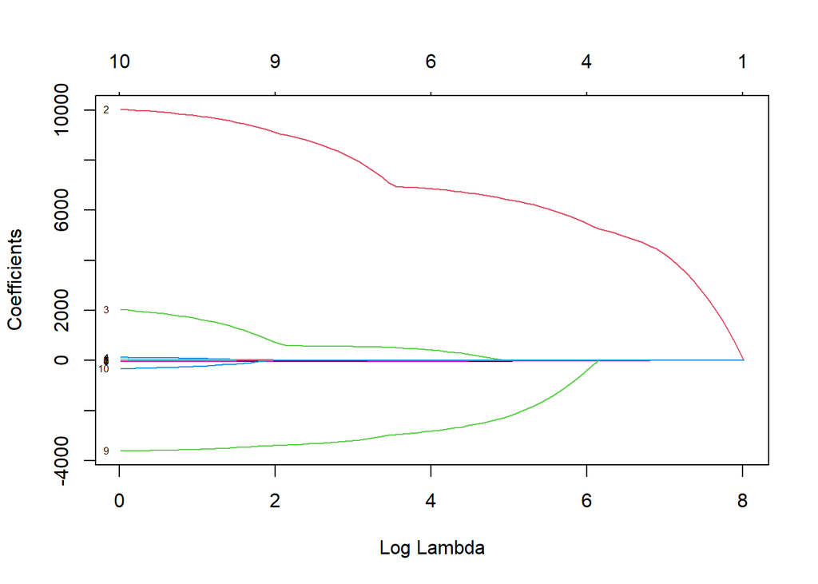

```r
# Training data
x <- model.matrix(Kvadratmeterpris ~ Kvadratmeter*Postnummer + Hustype*Postnummer + AntalVarelser + Byggeaar, train)[, -1]
y <- train$Kvadratmeterpris

# Fit Lasso model

lasso.mod <- glmnet(x, y, alpha = 1)

# Plot the coefficients
plot(lasso.mod, label=TRUE, xvar='lambda')
```

```r
# Extract the coefficients for the chosen lambda
lambda_chosen <- lasso.mod$lambda.min  # or any other value of lambda that you want to use
coef_lasso <- coef(lasso.mod, s = lambda_chosen)

lasso.mod.final <- glmnet(x, y, alpha = 1)
predict(lasso.mod.final,type='coefficients',s=lambda_chosen)
```

[output not shown]

[output cut: 246 more lines]

```
## Kvadratmeter:Postnummer2750       -9.819204   -10.03544   -10.24152   -10.44368
## Postnummer2720:HustypeRakkehus -3594.005322 -3599.64981 -3604.65462 -3609.86655
## Postnummer2750:HustypeRakkehus  -293.614247  -301.56220  -308.70341  -315.99827
##
## (Intercept)                    86022.38438 86005.19432
## Kvadratmeter                     -29.34657   -29.30344
## Postnummer2720                 10017.11899 10029.85570
## Postnummer2750                  2012.03983  2029.74242
## HustypeRakkehus                  118.11972   120.18265
## AntalVarelser                     42.92108    43.25892
## Byggeaar                         -32.06324   -32.05823
## Kvadratmeter:Postnummer2720      -23.42448   -23.52109
## Kvadratmeter:Postnummer2750      -10.64050   -10.77043
## Postnummer2720:HustypeRakkehus -3614.88530 -3618.37194
## Postnummer2750:HustypeRakkehus  -323.04552  -327.87742
```

```r
# Testing data
x_test <- model.matrix(Kvadratmeterpris ~ Kvadratmeter*Postnummer + Hustype*Postnummer + AntalVarelser + Byggeaar, test)[, -1]
y_test <- test$Kvadratmeterpris

# Make predictions using the Lasso model and calculate the RMSE
y_pred <- predict(lasso.mod.final, newx = x_test, s = lambda_chosen)
MSE_Lasso <- mean((y_test - y_pred)^2)
RMSE_Lasso <- sqrt(MSE_Lasso)
```

Opsumering af RMSE for de forskellige metoder:

```r
cat("RMSE_OLS:", RMSE_OLS, "\n")
```

```
## RMSE_OLS: 5719.674
```

```r
cat("RMSE_BSS:", RMSE_BSS, "\n")
```

```
## RMSE_BSS: 5483.507
```

```r
cat("RMSE_Ridge:", RMSE_Ridge, "\n")
```

```
## RMSE_Ridge: 5977.366
```

```r
cat("RMSE_Lasso:", RMSE_Lasso, "\n")
```

```
## RMSE_Lasso: 5733.575
```

Det virker til at BSS prædikterer bedst pt.

Jeg sammenligner koefficienter fra Lasso og BSS:

```r
print(coef_BSS)
```

```
##    (Intercept)   Kvadratmeter Postnummer2720
##    27420.12688      -58.33945     6419.14255
```

Sjovt nok virker det til at antallet af kvadratmetre reducerer kvadratmeterprisen (måske pga. mange kvadratmetre ikke er lig en lejlighed, hvor kvm prisen oftest er højere). Lasso straffer små beta værdier, hvorfor Lasso muligvis vil udlade variable som BSS ellers ville inkludere.

# Del 2: Lineære metoder til klassifikation

Jeg indlæser datasættet *Tilsalgs.txt* og opdeler i test-train 60-40 split:

```r
library(tidyverse)
library(caret)
library(glmnet)

Tilsalg <- read.delim("./Tilsalg.txt")
Tilsalg$Postnummer <- as.factor(Tilsalg$Postnummer)
Tilsalg <- select(Tilsalg, c('AntalVarelser', 'NetPrMd', 'Kvadratmeter', 'KvadratmeterGrund', 'Byggeaar', 'Kvadratmeterpris', 'Postnummer', 'Hustype', 'Solgt180'))

# Set the seed for reproducibility
set.seed(123)

# Split the dataset into train and test sets
trainIndex <- createDataPartition(Tilsalg$Solgt180, p = 0.6, list = FALSE)
train <- Tilsalg[trainIndex,]
test <- Tilsalg[-trainIndex,]

Solgt180_test <- test$Solgt180
```

## Almindelig logistisk regression

```r
library(pROC)

fit.logistic <- glm(Solgt180 ~ .,data=train,family='binomial')
summary(fit.logistic)
```

```
##
## Call:
## glm(formula = Solgt180 ~ ., family = "binomial", data = train)
##
## Deviance Residuals:
##     Min       1Q   Median       3Q      Max
## -1.9475  -0.9922  -0.6906   1.1385   2.5496
##
## Coefficients:
##                     Estimate Std. Error z value Pr(>|z|)
## (Intercept)       14.1157479 12.7999598   1.103   0.2701
## AntalVarelser     -0.2207703  0.1550130  -1.424   0.1544
## NetPrMd            0.0005156  0.0001173   4.395 1.11e-05 ***
## Kvadratmeter      -0.0646123  0.0147715  -4.374 1.22e-05 ***
## KvadratmeterGrund -0.0003023  0.0007788  -0.388   0.6979
## Byggeaar          -0.0034530  0.0064372  -0.536   0.5917
## Kvadratmeterpris  -0.0002665  0.0000652  -4.087 4.37e-05 ***
## Postnummer2720    -0.5402597  0.4030781  -1.340   0.1801
## Postnummer2750    -0.6128212  0.3397606  -1.804   0.0713 .
## HustypeRakkehus    0.1301326  0.4259935   0.305   0.7600
## ---
## Signif. codes:  0 '***' 0.001 '**' 0.01 '*' 0.05 '.' 0.1 ' ' 1
##
## (Dispersion parameter for binomial family taken to be 1)
##
##     Null deviance: 424.00  on 314  degrees of freedom
## Residual deviance: 389.76  on 305  degrees of freedom
## AIC: 409.76
##
## Number of Fisher Scoring iterations: 4
```

```r
pred.prob <- predict(fit.logistic, newdata = test, type='response')
pred.value <- 1*(pred.prob>0.5)
table(pred.value,Solgt180_test)
```

```
##           Solgt180_test
## pred.value FALSE TRUE
##          0    86   48
##          1    39   36
```

```r
mean(pred.value!=Solgt180_test)
```

```
## [1] 0.4162679
```

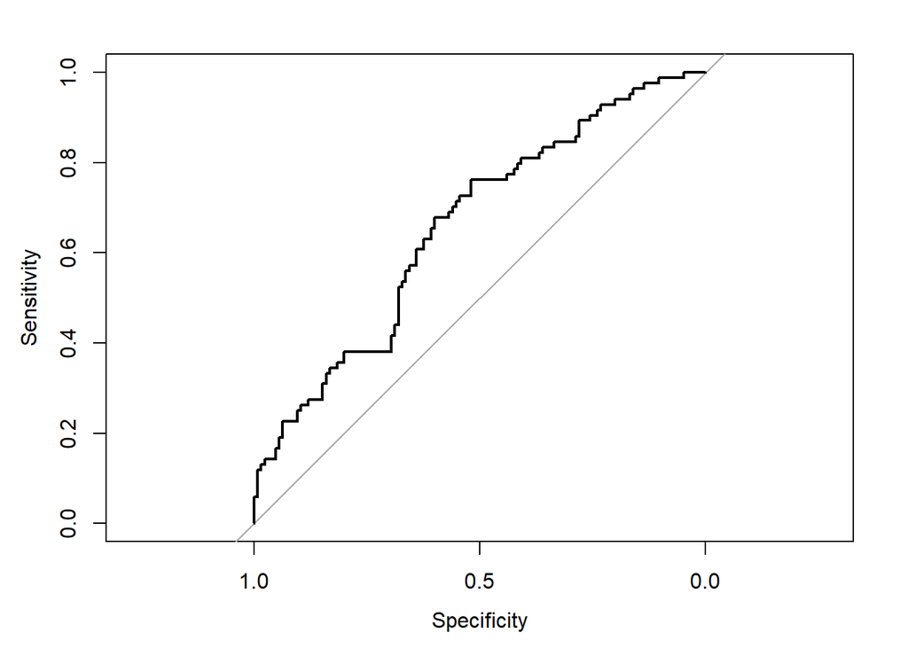

```r
plot(roc(Solgt180_test~pred.prob,direction='<'))
```

```r
auc(Solgt180_test~pred.prob,direction='<')
```

```
## Area under the curve: 0.6577
```

## Regulariseret logistisk regression (Ridge)

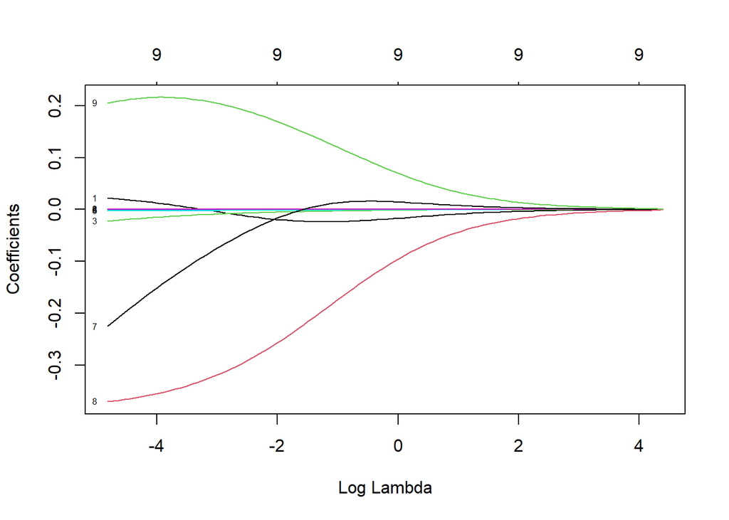

```r
# Create a vector of class labels (y)
y <- Tilsalg$Solgt180

# Create the design matrix (x)
x <- model.matrix(Solgt180 ~ ., data = Tilsalg)[,-1]

# Split the data into a 60-40 train-test split
train_index <- createDataPartition(y, p = 0.6, list = FALSE)
x_train <- x[train_index, ]
y_train <- y[train_index]
x_test <- x[-train_index, ]
y_test <- y[-train_index]


ridge.mod <- glmnet(x_train, y_train, alpha = 0, family = 'binomial')
plot(ridge.mod, label = TRUE, xvar = 'lambda')
```

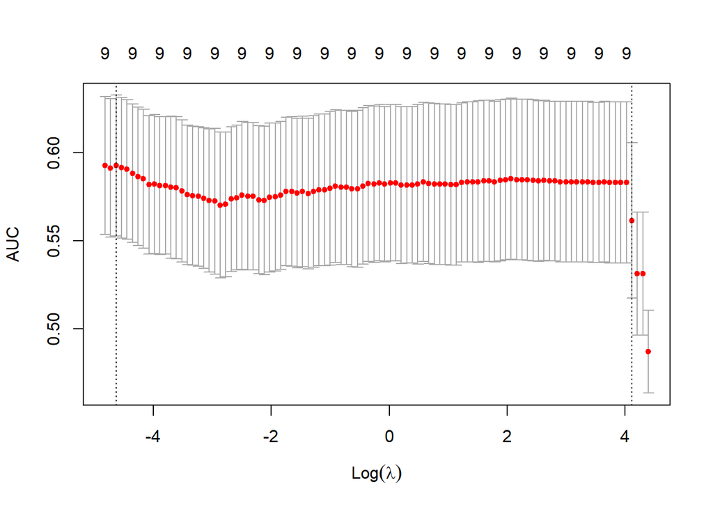

```r
cv.ridge.train <- cv.glmnet(x_train, y_train, alpha = 0, family = 'binomial', type.measure ='auc')
plot(cv.ridge.train)
```

```r
best.lambda <- cv.ridge.train$lambda.min
best.lambda
```

```
## [1] 0.009734877
```

```r
ridge.mod.final <- glmnet(x_train, y_train, alpha = 0)
predict(ridge.mod.final, type = 'coefficients', s = best.lambda)
```

```
## 10 x 1 sparse Matrix of class "dgCMatrix"
##                              s1
## (Intercept)        2.200215e+00
## AntalVarelser      5.971916e-03
## NetPrMd            3.774455e-05
## Kvadratmeter      -6.016811e-03
## KvadratmeterGrund -4.184552e-05
## Byggeaar          -6.349082e-04
## Kvadratmeterpris  -1.624005e-05
## Postnummer2720    -5.913239e-02
## Postnummer2750    -8.142373e-02
## HustypeRakkehus    5.794958e-02
```

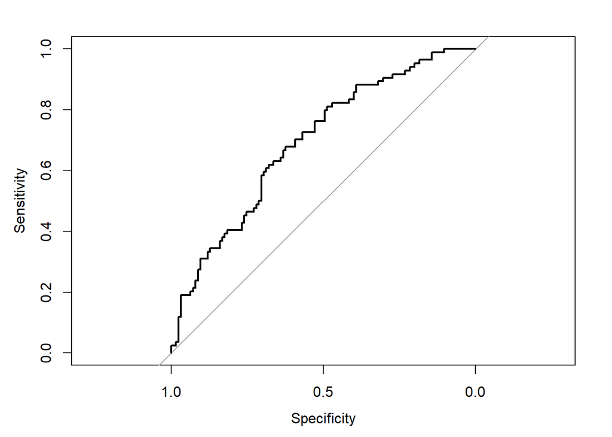

```r
# Optimize for auc in the test data set.
# If you want to optimize for error rate instead, use 'class' instead of 'auc'.
pred.prob.ridge <- as.vector(predict(ridge.mod.final, s = best.lambda, newx = x_test))
pred.value.ridge <- 1*(pred.prob.ridge > 0.5)

plot(roc(y_test ~ pred.prob.ridge, direction='<'))
```

```r
auc(y_test ~ pred.prob.ridge, direction='<')
```

```
## Area under the curve: 0.6927
```

```r
mean(pred.value.ridge != y_test)
```

```
## [1] 0.3588517
```

## Regulariseret logistisk regression (Lasso)

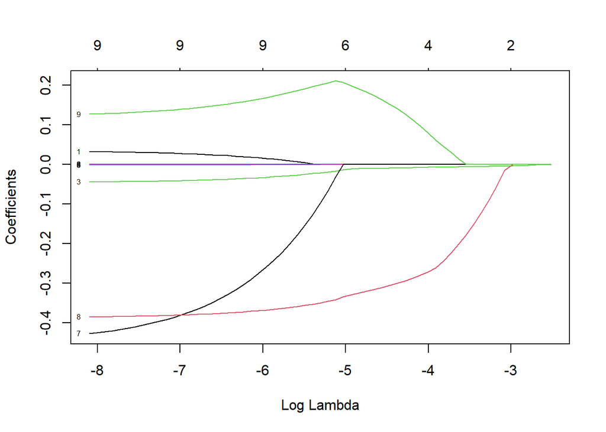

```r
# Fit the Lasso model on the training data
lasso.mod <- glmnet(x_train, y_train, alpha = 1, family = 'binomial')

# Plot the Lasso coefficient path
plot(lasso.mod, xvar = 'lambda', label = TRUE)
```

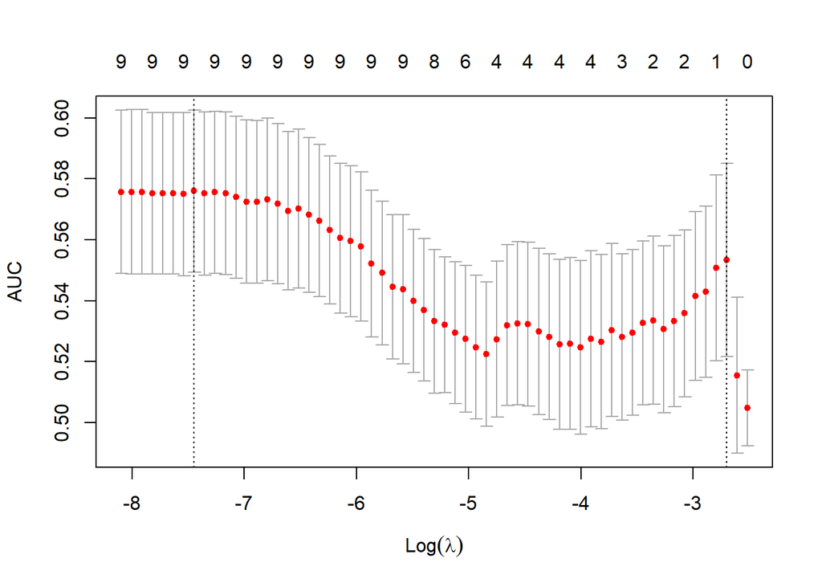

```r
# Perform cross-validation to select the best lambda value
cv.lasso.train <- cv.glmnet(x_train, y_train, alpha = 1, family = 'binomial', type.measure = 'auc')
plot(cv.lasso.train)
```

```r
# Get the best lambda value
best.lambda <- cv.lasso.train$lambda.min

# Fit the final Lasso model on the training data using the best lambda value
lasso.mod.final <- glmnet(x_train, y_train, alpha = 1)
predict(lasso.mod.final, type = 'coefficients', s = best.lambda)
```

```
## 10 x 1 sparse Matrix of class "dgCMatrix"
##                              s1
## (Intercept)        2.452764e+00
## AntalVarelser      6.625414e-03
## NetPrMd            5.862749e-05
## Kvadratmeter      -8.544649e-03
## KvadratmeterGrund -4.751248e-05
## Byggeaar          -6.249837e-04
## Kvadratmeterpris  -2.767628e-05
## Postnummer2720    -7.812505e-02
## Postnummer2750    -8.220026e-02
## HustypeRakkehus    5.543994e-02
```

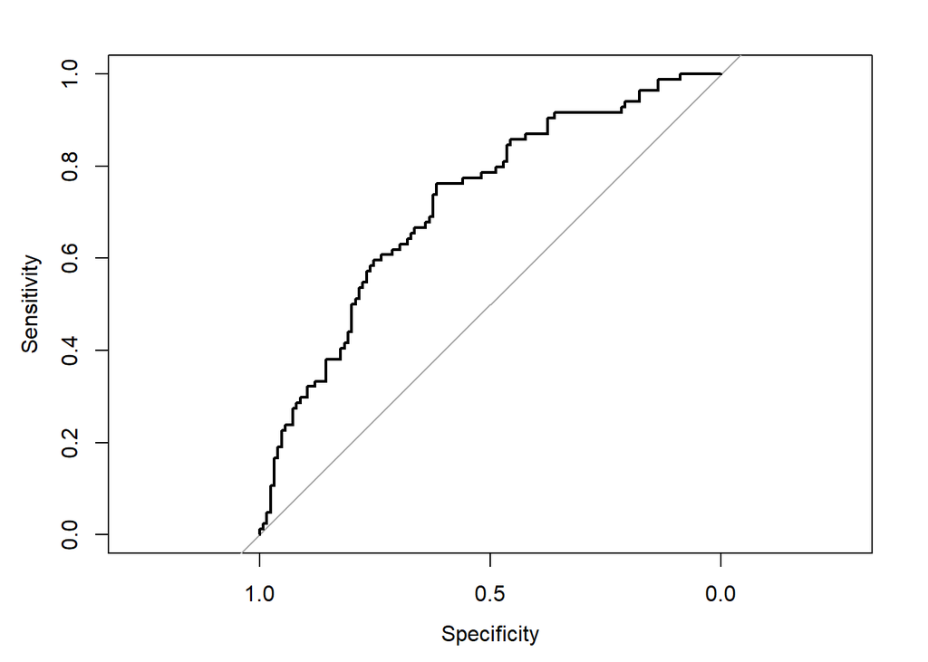

```r
# Make predictions on the test data using the final Lasso model
pred.prob.lasso <- as.vector(predict(lasso.mod.final, s = best.lambda, newx = x_test))
pred.value.lasso <- 1 * (pred.prob.lasso > 0.5)

# Plot the ROC curve and calculate the AUC
plot(roc(y_test ~ pred.prob.lasso, direction = '<'))
```

```r
auc(y_test ~ pred.prob.lasso, direction = '<')
```

```
## Area under the curve: 0.7199
```

```r
# Calculate the classification error rate
mean(pred.value.lasso != y_test)
```

```
## [1] 0.3349282
```

# LDA

```r
library(MASS)
library(pROC)

# Create a vector of class labels (y)
y <- Tilsalg$Solgt180

# Create the design matrix (x)
x <- model.matrix(Solgt180 ~ ., data = Tilsalg)[,-1]

# Split the data into a 60-40 train-test split
train_index <- createDataPartition(y, p = 0.6, list = FALSE)
x_train <- x[train_index, ]
y_train <- y[train_index]
x_test <- x[-train_index, ]
y_test <- y[-train_index]

# Fit LDA model to training data
lda.fit <- lda(x_train, y_train)

# Predict class labels for test data using LDA model
lda.pred <- predict(lda.fit, x_test)

# Calculate classification accuracy on test data
accuracy <- mean(lda.pred$class == y_test)
print(paste0("Classification accuracy: ", accuracy))
```

```
## [1] "Classification accuracy: 0.617224880382775"
```

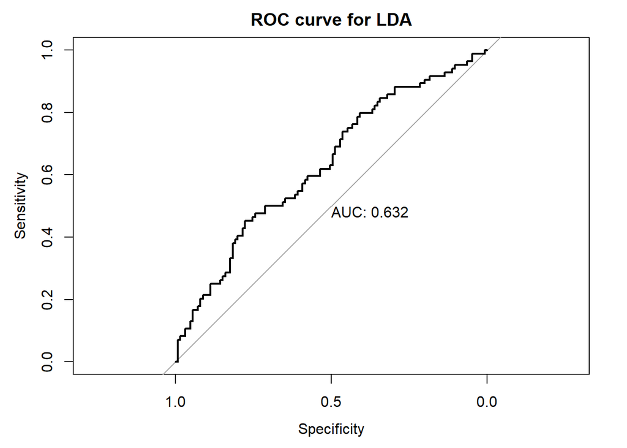

```r
# Plot ROC curve
roc.curve <- roc(y_test, lda.pred$posterior[,2])
plot(roc.curve, main = "ROC curve for LDA", print.auc = TRUE)
```

## QDA

```r
# Fit QDA model to training data
qda.fit <- qda(x_train, y_train)

# Predict class labels for test data using QDA model
qda.pred <- predict(qda.fit, x_test)

# Calculate classification accuracy on test data
accuracy <- mean(qda.pred$class == y_test)
print(paste0("Classification accuracy: ", accuracy))
```

```
## [1] "Classification accuracy: 0.574162679425837"
```

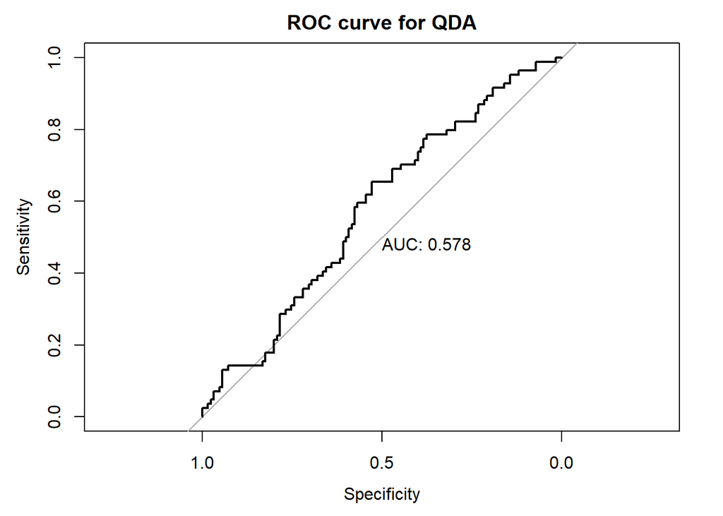

```r
# Plot ROC curve
roc.curve <- roc(y_test, qda.pred$posterior[,2])
plot(roc.curve, main = "ROC curve for QDA", print.auc = TRUE)
```

# Del 3: Illustration af virkningen af ridge og lasso mht. bias og varians

Grundideen er at simulere data fra den lineære model

$Y = \beta_0 + \beta_1X_1 +\beta_2X_2 + \beta_3X_3 + \beta_4X_4 + \beta_5X_5 + \beta_6X_6 + \xi$

Nedenfor simuleres data

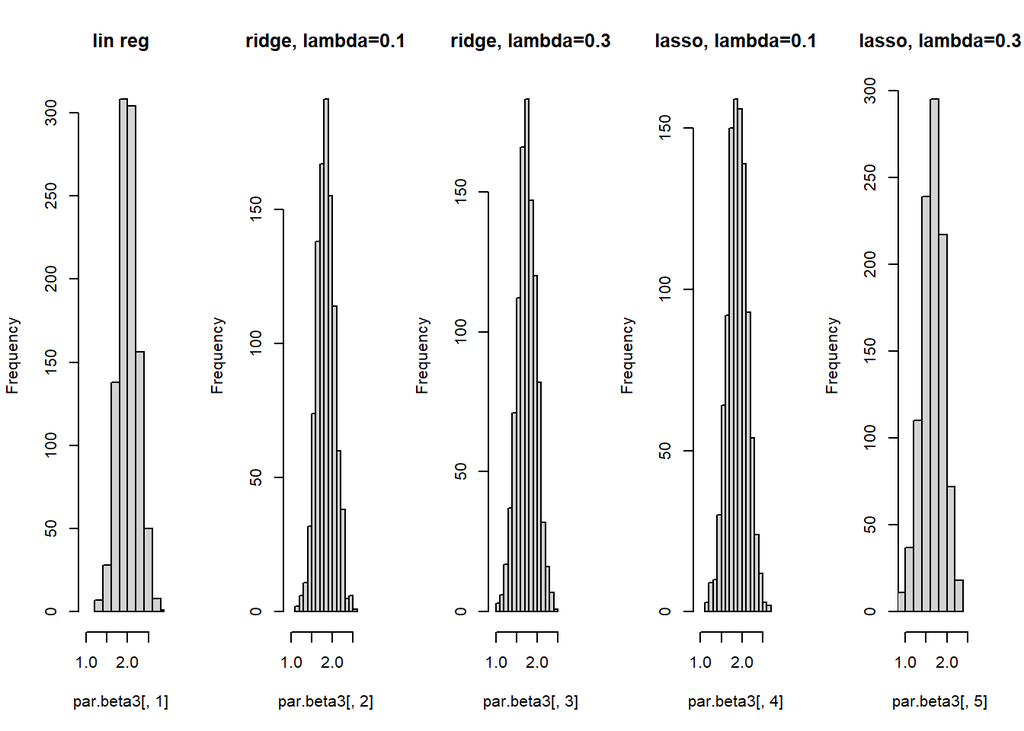

```r
library(glmnet)
set.seed(1)
nsim<-1000
N<-25
beta<-c(2,0.5,-0.6,2,0.001,0,-1)


par.beta3<-matrix(rep(NA,5*nsim),ncol=5)
par.beta5<-matrix(rep(NA,5*nsim),ncol=5)

ypred.linreg<-rep(0,nsim)
ypred.ridge01<-rep(0,nsim)
ypred.ridge03<-rep(0,nsim)
ypred.lasso01<-rep(0,nsim)
ypred.lasso03<-rep(0,nsim)

xtest<-c(1,rnorm(6))
for (i in 1:nsim){



## x-variable
x1<-rnorm(N)
x2<-rnorm(N)
x3<-rnorm(N)
x4<-rnorm(N)
x5<-rnorm(N)
x6<-rnorm(N)

## x-matrix, y-variabel og fuldt datasæt
y<-beta[1]+beta[2]*x1+beta[3]*x2+beta[4]*x3+beta[5]*x4+beta[6]*x5+beta[7]*x6+rnorm(N)
x<-model.matrix(y~x1+x2+x3+x4+x5+x6)[,-1]

dataset<-cbind.data.frame(y,x1,x2,x3,x4,x5,x6)

## lineær regression

lin.model<-lm(y~x1+x2+x3+x4+x5+x6,data=dataset)
lin.koeff<-as.vector(lin.model$coefficients)

## ridge
ridge.mod<-glmnet(x,y,alpha=0)
ridge.koeff01<-predict(ridge.mod,type='coefficients',s=0.1)
ridge.koeff03<-predict(ridge.mod,type='coefficients',s=0.3)

## lasso

lasso.mod<-glmnet(x,y,alpha=1)
lasso.koeff01<-predict(lasso.mod,type='coefficients',s=0.1)
lasso.koeff03<-predict(lasso.mod,type='coefficients',s=0.3)


## beta3 og beta5 gemmes
par.beta3[i,]<-c(lin.koeff[4],ridge.koeff01[4],ridge.koeff03[4],lasso.koeff01[4],lasso.koeff03[4])
par.beta5[i,]<-c(lin.koeff[6],ridge.koeff01[6],ridge.koeff03[6],lasso.koeff01[6],lasso.koeff03[6])

## prædiktion af y-værdi med de 5 sæt koefficienter
ypred.linreg[i]<-sum(lin.koeff*xtest)
ypred.ridge01[i]<-sum(ridge.koeff01*xtest)
ypred.ridge03[i]<-sum(ridge.koeff03*xtest)
ypred.lasso01[i]<-sum(lasso.koeff01*xtest)
ypred.lasso03[i]<-sum(lasso.koeff03*xtest)

}


#### histogrammer, der viser estimater af beta3. Den sande værdi er 2
par(mfrow=c(1,5))
hist(par.beta3[,1],xlim=c(0.9,2.8),main='lin reg')
hist(par.beta3[,2],xlim=c(0.9,2.8),main='ridge, lambda=0.1')
hist(par.beta3[,3],xlim=c(0.9,2.8),main='ridge, lambda=0.3')
hist(par.beta3[,4],xlim=c(0.9,2.8),main='lasso, lambda=0.1')
hist(par.beta3[,5],xlim=c(0.9,2.8),main='lasso, lambda=0.3')
```

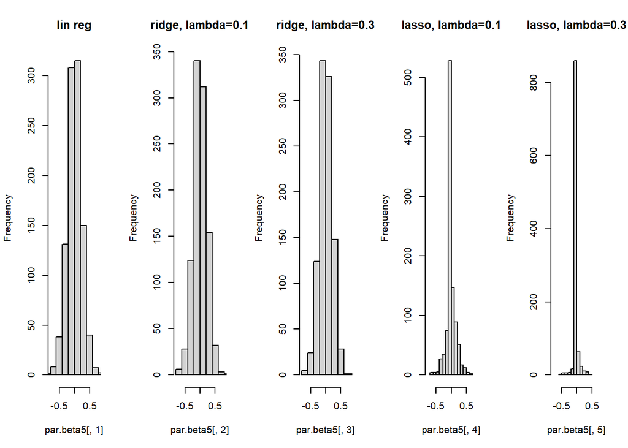

```r
#### histogrammer, der viser estimater af beta5. Den sande værdi er 0
hist(par.beta5[,1],xlim=c(-0.8,0.8),main='lin reg')
hist(par.beta5[,2],xlim=c(-0.8,0.8),main='ridge, lambda=0.1')
hist(par.beta5[,3],xlim=c(-0.8,0.8),main='ridge, lambda=0.3')
hist(par.beta5[,4],xlim=c(-0.8,0.8),main='lasso, lambda=0.1')
hist(par.beta5[,5],xlim=c(-0.8,0.8),main='lasso, lambda=0.3')
```

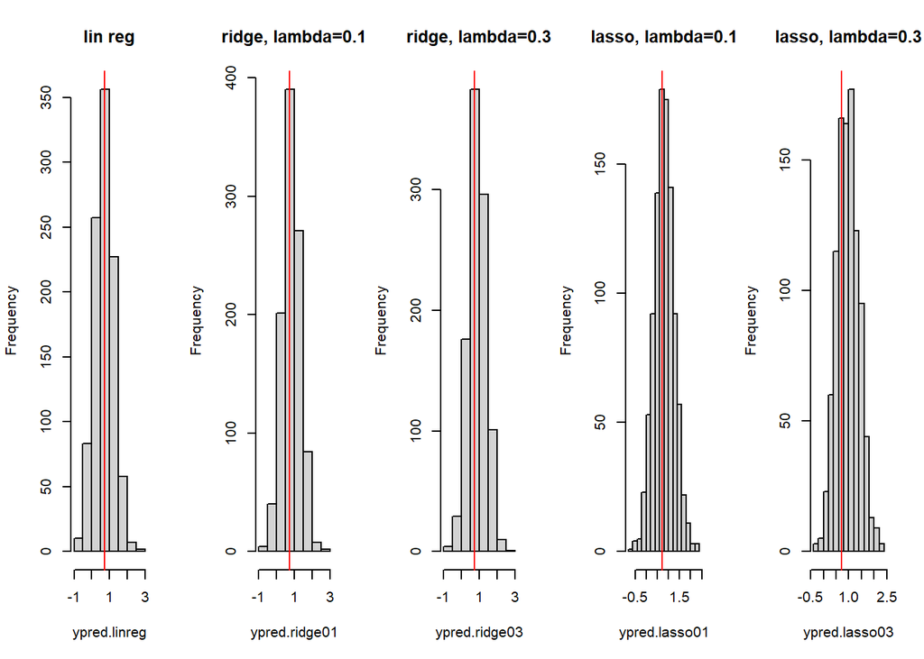

```r
#### histogrammer, der viser prædiktioner af y. Den sande forventede værdi er indtegnet
hist(ypred.linreg,main='lin reg')
abline(v=sum(beta*xtest),col='red')
hist(ypred.ridge01,main='ridge, lambda=0.1')
abline(v=sum(beta*xtest),col='red')
hist(ypred.ridge03,main='ridge, lambda=0.3')
abline(v=sum(beta*xtest),col='red')
hist(ypred.lasso01,main='lasso, lambda=0.1')
abline(v=sum(beta*xtest),col='red')
hist(ypred.lasso03,main='lasso, lambda=0.3')
abline(v=sum(beta*xtest),col='red')
```

```r
#### gennemsnit og varianser af de prædikterede værdier
sum(beta*xtest)  # sand forventet værdi
```

```
## [1] 0.7273935
```

```r
mean(ypred.linreg); mean(ypred.ridge01); mean(ypred.ridge03); mean(ypred.lasso01); mean(ypred.lasso03)
```

```
## [1] 0.7186694
```

```
## [1] 0.8360991
```

```
## [1] 0.8914815
```

```
## [1] 0.8133961
```

```
## [1] 0.9643854
```

```r
var(ypred.linreg); var(ypred.ridge01); var(ypred.ridge03); var(ypred.lasso01); var(ypred.lasso03)
```

```
## [1] 0.2919047
```

```
## [1] 0.2454203
```

```
## [1] 0.2375596
```

```
## [1] 0.2025846
```

```
## [1] 0.1851235
```

Umiddelbart ser det ud til, at OLS er den der prædikterer, men har størst varians. Det er klart at for højere værdi af $\lambda$ desto mere straffer Ridge og Lasso $\beta_3$-koefficienten. Lasso og Ridge straffer den hårdere, da $\beta_3$ er en relativ stor koefficient. For $\beta_5$ prædikterer Ridge og Lasso bedre og for $\lambda = 0.3$ er Lasso klart den bedste med meget lille varians. Det skyldes at Lasso straffer små $\beta$ værdier meget hårdt. Og da $\beta_5=0$ virker det meget intutivt at den oftest estimeres til 0 i Lasso. Ridge prædikterer også bedre, men med større varians end Lasso. Eftersom Ridge kun konverger imod 0. Dog har både Lasso og Ridge lavere varians nu end OLS.

For de prædikterede værdier ses det at OLs har den største varians men er bedst til at prædiktere rigtig (grundet mindre bias). Hvor at Ridge og Lasso modellerne for $\lambda=0.3$ er dårligst til at prædiktere i gennemsnit. Til gengæld har de en lavere varians. Hvilket nok skylder, at de neglicerer nogle af $\beta$ koefficienterne, hvorfor de har højere bias og lavere varians. Alt i alt vil jeg nok foretrække en standard OLS model i det her tilfælde. Eftersom den prædikterer langt bedre i snit end de andre, uden at variansen virker meget højere.